# Final Project - Option 2

2024-10-15

## Introduction

The human brain structural connectome, defined here as the collection of white matter fiber tracts connecting different regions of the brain (see Park and Friston 2013),(Fornito, Zalesky, and Breakspear 2013),(Craddock et al. 2013) and (Jones, Knosche, and Turner 2013), plays a crucial role in how the brain responds to everyday tasks and life’s challenges. There has been a huge interest in studying connectomes and understanding how they vary for individuals in different groups according to traits and substance exposures. Such studies have typically focused on functional connectomes instead of structural connectomes (see Park and Friston 2013), (Finn et al. 2015), (Bjork and Gilman 2014), (Smith et al. 2015), and (Price 2012), due to the difficulty of recovering reliable structural connectomes (Maier-Hein et al. 2017), (Reveley et al. 2015). If you are interested to learn more, you can download and read these papers.

Recent advances in noninvasive brain imaging and preprocessing have produced huge brain imaging datasets (e.g., the Human Connectome Project (Van Essen et al. 2013) and the UK Biobank (Miller et al. 2016)) along with sophisticated tools to routinely extract brain structural connectomes for different individuals. We will mainly focus on the Humcan Connectome Project. You can get an overview of this project from (https://www.humanconnectome.org/). You will find that there are different studies: Young Adult HCP, Lifespan HCP and so on. We will focus on the Yong Adult HCP. **For students who decided to choose this project, you need to register an account at (https://db.humanconnectome.org/) to agree with their data usage terms.**

Relying on high quality imaging data and many different traits for a large number of study participants obtained in the Human Connectome Project (HCP) we can extract reliable structural connectomes and different traits and substance exposures measures. The goal of this project is to analyze relationships between them.

**Human Connectome Project (HCP)**. The HCP aims to characterize human brain connectivity in about $1,200$ healthy adults and to enable detailed comparisons between brain circuits, behavior and genetics at the level of individual subjects. Customized scanners were used to produce high-quality and consistent data to measure brain connectivity. The latest release in 2017, containing various traits, structural MRI (sMRI) and diffusion MRI (dMRI) data for $1065$ healthy adults, can be easily accessed through ConnectomeDB. The rich trait data, high-resolution dMRI and sMRI make it an ideal data set for studying relationships between connectomes and human traits.

(Some background on diffusion MRI, not necessary to understand everything) A full diffusion MRI session in HCP includes 6 runs (each approximately 10 minutes), representing 3 different gradient tables, with each table acquired once with right-to-left and left-to-right phase encoding polarities, respectively. Each gradient table includes approximately $90$ diffusion weighting directions plus 6 $b_0$ acquisitions interspersed throughout each run. Within each run, there are three shells of $b=1000, 2000$, and $3000$ s/mm$^2$ interspersed with an approximately equal number of acquisitions on each shell. The directions were optimized so that every subset of the first $N$ directions is also isotropic. The scan was done by using the Spin-echo EPI sequence on a 3 Tesla customized Connectome Scanner. See (Van Essen et al. 2012) for more details about the data acquisition of HPC. Such settings give the final acquired image with isotropic voxel size of $1.25$ mm, and $270$ diffusion weighted scans distributed equally over $3$ shells.

We then segement the whole brain into a few regions of interest so that we can extract a connectivity matrix for each subject to describe which brain regions are connected. Usually, this step is done by utlizing some well known atlas/template predefined by brain anatomist. One of the most common one is called Desikan-Killiany atlas. The Desikan-Killiany atlas parcellate the brain into 68 cortical surface regions with 34 nodes in each hemisphere. Freesurfer software can be used to perform brain registration and parcellation. Figure 1 column (a) illustrates the Desikan-Killiany parcellation and a reconstructed tractography data after subsampling.

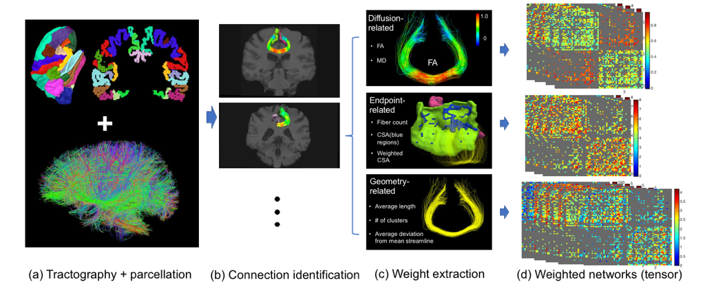

**Figure 1** - Pipeline of the preprocessing steps to extract weighted networks from the dMRI and sMRI image data. (a) Desikan-Killiany parcellation and the tractography data for an individual’s brain; (b) extraction of streamlines between two ROIs; (c) feature extraction from each connection and (d) extracted weighted networks.

**Traits**. You can find many covariates in the folder of `Data/traits` (i.e., `table1_hcp.csv` and `table2_hcp.csv`) and data dictionary in `HCP_S1200_DataDictionary_Sept_18_2017.xls`. A subfolder named `175traits` contains 175 traits that I previously identified. These traits measure a person’s cognition, substance use, psychiatric and life function, sensory, emotion, health and family history.

**Structural and Functional Connectomes**. In the folder `SC` and `FC` you can find Structural Connectomes and Functional Connectomes for about 1065 subjects, respectively.

**Structural Connectome Dimention Reduction** Let’s assume we extract M different features from each connection. By doing this, we have a $68 \times 68 \times M$ matrix (for the Desikan Parcellation. You might see $87\times 87$ or other dimensions if a different parcellation is used to construct the SC or FC) representing each subject’s structural connectome. If you calculate the number of variables inside such tensor, it should be $(68*67/2)*M = 2278*M$ (because of the symmetry of the matrix). If $M = 10$, you have about 22k unknown variables. Usually, with such large unknown variables and such small sample size, we are facing challenges in modeling. For example, a simple linear regression will not work (why?). Let’s say, we are interested in using these connectivity features to predict a score measured from a subject, which model can we use?

A few ways to get around the high dimensional issue include: (1) if you want to use a regression method, you can perform a penalize regression, for example, rigid regression or LASSO; (2) reduce the dimension of the connectivity matrix. There are many ways for (2) - for example, you can treat the matrix as a set of network and extract summary statistics from these networks. Depending on how many of summaries you extract, you will have different low dimensional representation of the connectome. Another way is to vectorize the data and perform PCA analysis. However, vectorizing the tensor would discard valuable information about the network structure. Here we take a different approach - we treat this set of networks for all subjects as a high-dimensional tensor and perform a tenor PCA.

The tensor PCA (TNPCA) approach approximates the brain tensor network using $K$ components, with the components ordered to have decreasing impact similarly to common practice in PCA. Individuals are assigned a brain connectome PC score for each of the $K$ components, measuring the extent to which their brain tensor network expresses that particular tensor network (TN) component. Each TN component is itself a tensor network, but one having a very simple rank one structure depending on scores for each brain ROI. By using TN-PCA, we can replace the high dimensional tensor network summarizing an individual’s brain connectome with a $K$-dimensional vector of brain PC scores; these scores can be used for visualizing variation among individuals in their brain connectomes and in statistical analyses studying relationships between connectomes and traits. You can find matlab code for performing TNPCA here: https://github.com/zhengwu/TensorNetwork_PCA. By setting `K=60`, I calculated the TN-PCA coefficient scores for each subject and you can find these scores in the folder `TNPCA_Result` if you want to utilize such data in your project.

**Network data embedding**. Loosely, there are two types of embedding: 1. you can embed the whole network into a vector in a low-dimensional space; and 2. you can embed each network node into a vector space. In the later case, the spatial distribution of nodes in the embedding space would represent the relationship among them, e.g., connected nodes will stay close to each other. There is a large body of literature for this thread (e.g, embedding of large scale graphs and so on). A very recent paper is by Arroyo et al. (Arroyo et al. 2019) that you can read and implement for this project (he has R and Python code, check his website: https://jesus-arroyo.github.io/papers/)

**Load data**. The matlab code “load_data.m” show you how to load data to matlab. You can `R.matlab` package in R to load `.mat` file to R.

# Final project questions (suggested)

For the final project, your tasks can be simply summarized as follows:

# Merge data or data management

For each subject, you have network data, PCA scores, and covariates. Start to think about how to store them in an efficient way to faciliate your modeling and visualization.

# Plots or data visulization

Before writing down any models, EDA is encouraged. Visualize your data and try to see whether there are interesting patterns/trends inside. Here we are interested in exploring the relationship between traits and brain connectomes. I will suggest to 1) reduce the dimension of the network data into a vector (e.g., with dimenion of 3 so you can plot them), 2) visulize the embedded networks and explore their relationship with some traits (e.g., cognition or motion).

What you can do is to sort all subjects according to some trait, take out the first N and last N subjects (e.g., N=50,100,200), plot their first 3 PC scores, and color each subject with the trait score. Choose some interesting ones to display and explain their meaning.

# Study the relationship

To study the relationship between traits and connectomes, you can do: 1. hypothesis tests and 2. prediction and other interesting statistical analyses that you know well (or you want to study).

Note that some of the traits are discrete and some of them are continuous. You might want to use different models for different types of covariates.

For hypothesis tests, what you can do is to choose a trait, sort the subject, get N subjects with high trait values and get M subjects with low trait values, assign them to high and low classes. Next, you test the mean difference between their connectomes and/or PC scores.

If you only test the first PC scores, you can use t-test. However, if you want to test mean difference for multivariate data (with dim>1), you need to do more research (e.g., which method will work in this case). Try to find some R/Matlab package can do this type of hypothese testing.

For prediction analysis, I suggest you try different models, e.g., linear regression, rigid regression, SVM, random forest and so on. Choose some traits that are interesting to you, and try use different models and evaluate whether brain connectomes can predict traits. That is whether you brain connectivity can predict your cognition, emotion and so on.

**References**

Arroyo, Jesús, Avanti Athreya, Joshua Cape, Guodong Chen, Carey E Priebe, and Joshua T Vogelstein. 2019. “Inference for Multiple Heterogeneous Networks with a Common Invariant Subspace.” *arXiv Preprint arXiv:1906.10026*.

Bjork, James M, and Jodi M Gilman. 2014. “The Effects of Acute Alcohol Administration on the Human Brain: Insights from Neuroimaging.” *Neuropharmacology* 84: 101–10.

Craddock, R Cameron, Saad Jbabdi, Chao-Gan Yan, Joshua T Vogelstein, F Xavier Castellanos, Adriana Di Martino, Clare Kelly, Keith Heberlein, Stan Colcombe, and Michael P Milham. 2013. “Imaging Human Connectomes at the Macroscale.” *Nature Methods* 10 (6): 524–39.

Finn, Emily S, Xilin Shen, Dustin Scheinost, Monica D Rosenberg, Jessica Huang, Marvin M Chun, Xenophon Papademetris, and R Todd Constable. 2015. “Functional Connectome Fingerprinting: Identifying Individuals Using Patterns of Brain Connectivity.” *Nature Neuroscience* 18 (11): 1664–71.

Fornito, Alex, Andrew Zalesky, and Michael Breakspear. 2013. “Graph Analysis of the Human Connectome: Promise, Progress, and Pitfalls.” *Neuroimage* 80: 426–44.

Girard, Gabriel, Kevin Whittingstall, Rachid Deriche, and Maxime Descoteaux. 2014. “Towards Quantitative Connectivity Analysis: Reducing Tractography Biases.” *NeuroImage* 98: 266–78.

Jones, D. K., T. R. Knosche, and R. Turner. 2013. “White matter integrity, fiber count, and other fallacies: the do’s and don’ts of diffusion MRI.” *Neuroimage* 73 (June): 239–54.

Maier-Hein, Klaus H, Peter F Neher, Jean-Christophe Houde, Marc-Alexandre Côté, Eleftherios Garyfallidis, Jidan Zhong, Maxime Chamberland, et al. 2017. “The Challenge of Mapping the Human Connectome Based on Diffusion Tractography.” *Nature Communications* 8 (1): 1349.

Miller, Karla L, Fidel Alfaro-Almagro, Neal K Bangerter, David L Thomas, Essa Yacoub, Junqian Xu, Andreas J Bartsch, et al. 2016. “Multimodal Population Brain Imaging in the UK Biobank Prospective Epidemiological Study.” *Nature Neuroscience* 19 (11): 1523.

Park, Hae-Jeong, and Karl Friston. 2013. “Structural and Functional Brain Networks: From Connections to Cognition.” *Science* 342 (6158): 1238411.

Price, Cathy J. 2012. “A Review and Synthesis of the First 20 Years of PET and fMRI Studies of Heard Speech, Spoken Language and Reading.” *Neuroimage* 62 (2): 816–47.

Reveley, Colin, Anil K Seth, Carlo Pierpaoli, Afonso C Silva, David Yu, Richard C Saunders, David A Leopold, and Q Ye Frank. 2015. “Superficial White Matter Fiber Systems Impede Detection of Long-Range Cortical Connections in Diffusion MR Tractography.” *Proceedings of the National Academy of Sciences* 112 (21): E2820–28.

Smith, Stephen M, Thomas E Nichols, Diego Vidaurre, Anderson M Winkler, Timothy EJ Behrens, Matthew F Glasser, Kamil Ugurbil, Deanna M Barch, David C Van Essen, and Karla L Miller. 2015. “A Positive-Negative Mode of Population Covariation Links Brain Connectivity, Demographics and Behavior.” *Nature Neuroscience* 18 (11): 1565–67.

Van Essen, David C, Stephen M Smith, Deanna M Barch, Timothy EJ Behrens, Essa Yacoub, Kamil Ugurbil, Wu-Minn HCP Consortium, et al. 2013. “The WU-Minn Human Connectome Project: An Overview.” *Neuroimage* 80: 62–79.

Van Essen, David C, Kamil Ugurbil, E Auerbach, D Barch, TEJ Behrens, R Bucholz, Acer Chang, et al. 2012. “The Human Connectome Project: A Data Acquisition Perspective.” *Neuroimage* 62 (4): 2222–31.